# Prediction on Titanic Survivors

André Jakob

17/06/2019

## Introduction

### Cleaning the data set

The first step of the analysis is to take a look on the data. It was downloaded as a xls file, which I put in a R vector. Some of the numeric observations was originally imputed as characters, but R has coerced those automatically to numeric.

```r
dim(titanic)
```

```
## [1] 1309    9
```

A first look on the data set shows us that we have 1309 observations, in other words passangers, and 14 variables: “pclass”, “survived”, “name”, “sex”, “age”, “sibsp”, “parch”, “ticket”, “fare”, “cabin”, “embarked”, “boat”, “body” and “home.dest”. Not all of these variables seem usefull to base the prediction, so I selected only 8 who seem meaningfull. The variables elected as non important are: name, cabin, boat, body and destination. I discarded name and destination because sounds obvious to me that these variables could not interfere in the survival rate of the passager. Cabin and boat could have been usefull, but unfortunately there are too many NA’s in their columns - even more than actual data (see below), so it would be too risky infere their values. And the classification of body is already a sign that the person did not survive (even though there are many NA’s between the non survivals). There is some subjectiveness in my choices, but I do not see them as very controversial and believe my explanation above is enough.

```r
kable(nas0)
```

| pclass | survived | sex | age | sibsp | parch | fare | embarked | cabin | boat |
| --- | --- | --- | --- | --- | --- | --- | --- | --- | --- |
| 0 | 0 | 0 | 263 | 0 | 0 | 1 | 2 | 1014 | 823 |

### Variables

So at the end we have a data set with 8 variables, which I briefly explain:

#### “pclass” referes to the class of the passagers, it has 3 possible values (1, 2 or 3).

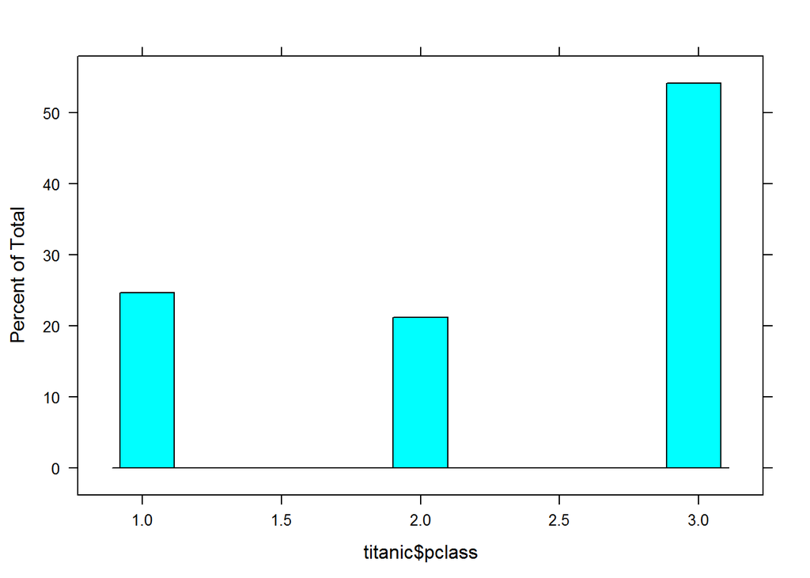

```r
histogram(titanic$pclass)
```

#### “survived” is the goal of prediction, and has 2 possible outcomes (1 for survived and 0 for not survived).

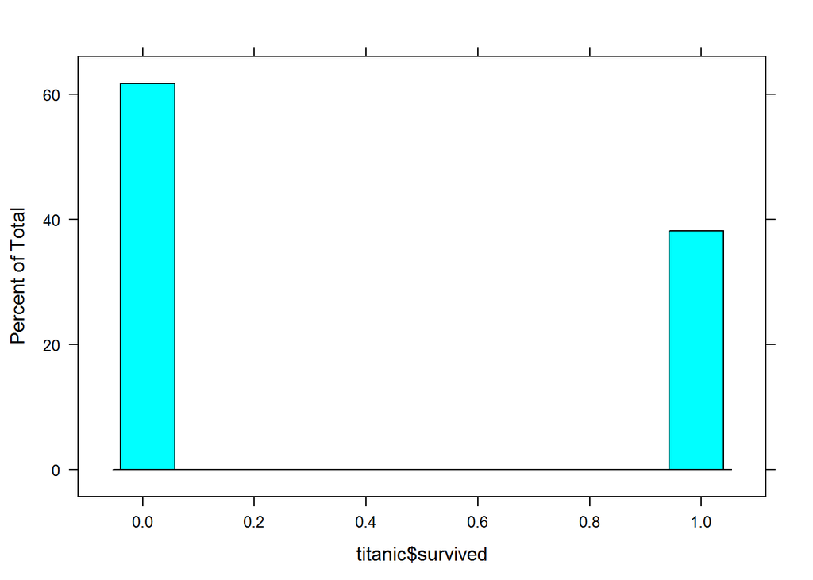

```r
histogram(titanic$survived)
```

#### “sex” (male or female).

```r
sex<-data.frame(Male=sum(titanic$sex=="male"),Female=sum(titanic$sex=="female"))
sex
```

```
##   Male Female
## 1  843    466
```

#### “age” is a continuous distribution of the age in years from each passager. As showed above, there are 263 NAs on the data set, so I will not plot this distribution nor analyse it further at this moment.

#### “sibsp” and “parch” are similar. The first one is the number of brothers, sisters or spouses while the second one is the number of parents and children each passanger has on board. At this point I created a new variable “family” to compute the size of the families on board, which is the sum of “parch” and “sibsp” plus 1 (the passager himself).

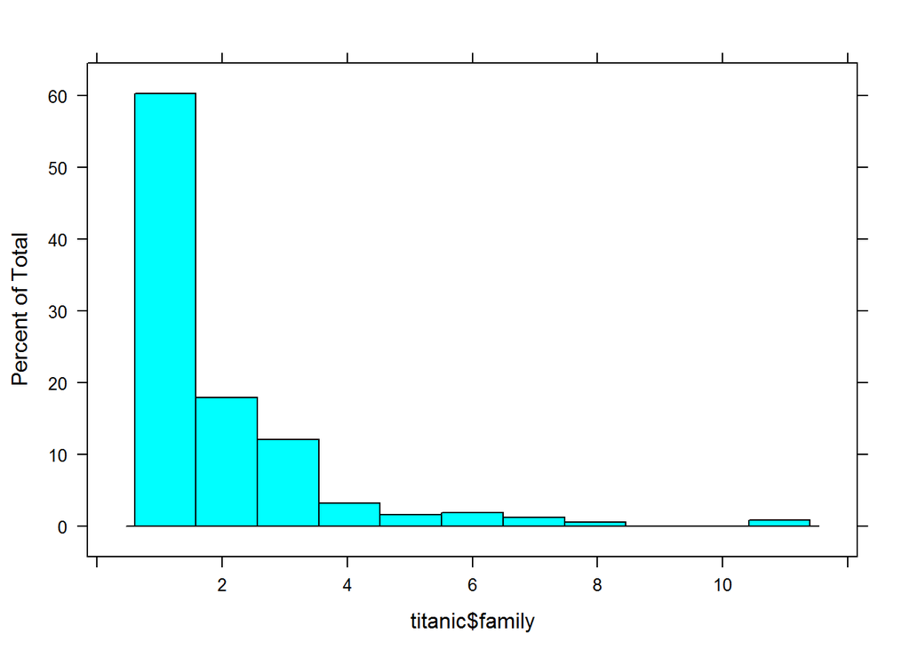

```r
titanic$family<-titanic$sibsp+titanic$parch+1
histogram(titanic$family)
```

```r
titanic[is.na(titanic$fare),]
```

[output not shown]

```r
titanic$fare[is.na(titanic$fare)]<-median(titanic$pclass==3&titanic$embarked=="S", na.rm=TRUE)
sum(is.na(titanic$fare))
```

```
## [1] 0
```

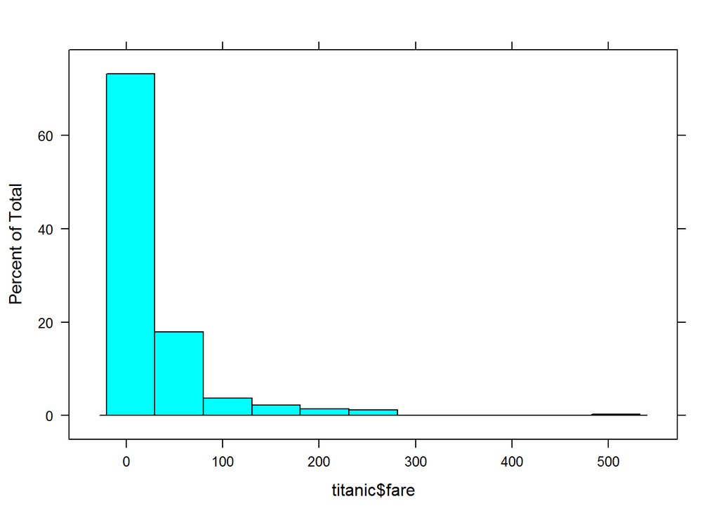

```r
histogram(titanic$fare)
```

```r
embarked<-titanic%>%filter(fare>=79&fare<=80&pclass=="1"&family=="1")
embarked
```

```
## # A tibble: 6 x 9
##   pclass survived sex      age sibsp parch  fare embarked family
##    <dbl>    <dbl> <fct>  <dbl> <dbl> <dbl> <dbl> <fct>     <dbl>
## 1      1        0 male    24       0     0  79.2 C             1
## 2      1        0 male    46       0     0  79.2 C             1
## 3      1        1 female  38       0     0  80   Q             1
## 4      1        0 male    46       0     0  79.2 C             1
## 5      1        1 female  62       0     0  80   Q             1
## 6      1        1 female  39.5     0     0  79.2 C             1
```

```r
titanic$embarked[is.na(titanic$embarked)]<-"Q"
sum(is.na(titanic$embarked))
```

```
## [1] 0
```

```r
ports<-data.frame("South Hampton"=(sum(titanic$embarked=="S")),Cherbourg=(sum(titanic$embarked=="C")),Queenstown=(sum(titanic$embarked=="Q")))
kable(ports)
```

| South.Hampton | Cherbourg | Queenstown |
| --- | --- | --- |
| 914 | 270 | 125 |

### First minor Machine Learning

As it is showed above, most of the variables have been cleaned and are ready for the prediction. There is though the column Age with several NAs in it (exactly 263). Unfortunately this seems to be an important criteria for survival and I can not give up on this. Since age usually follows a normal distribution, I could have been corrected the NA values with a median of the non NAs values. Nevertheless, I choosed to run a first minor Machine Learning experiment to fill the NAs. Using the Regression Trees technique I created a fit modell function to predict age from all other variables from the non-NAs (except survived, which is the final goal). Then I used predict function to fill the NAs, which gave me a age distribution that I show below.

```r
fit_age<-rpart(age~pclass+sex+sibsp+parch+fare+embarked+family,data=titanic[!is.na(titanic$age),])

titanic$age[is.na(titanic$age)]<-predict(fit_age,titanic[is.na(titanic$age),])

sum(is.na(titanic$age))
```

```
## [1] 0
```

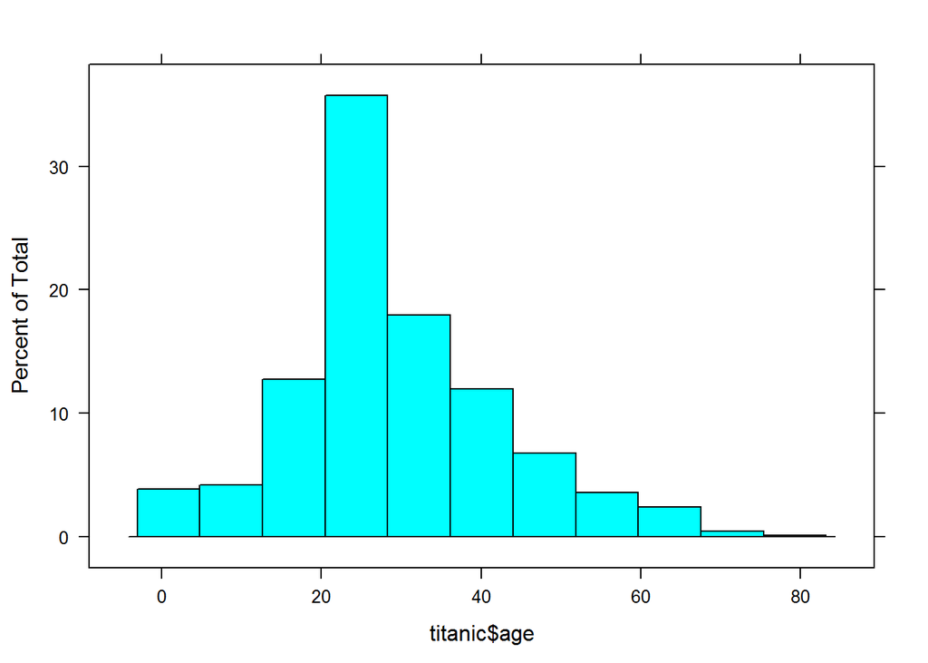

```r
histogram(titanic$age)
```

### Splitting train and test set

Now that the data set is clean, I divided it into a training and a test set. It was common during the course to stablish a proportion of 0.1 between training and test set. But here the entire data set is not so large (1309 rows), so I choosed a higher proportion of 0.3. After separating both sets, I removed the “survived” color from the test set, in order to predict this information based on the training set.

```r
kable(traintest[1,])
```

| test | train |
| --- | --- |
| 393 | 916 |

### Regression Tree

Again I used the Regression Trees technique I created a fit modell function to predict if the passanger has or has not survived from all other variables. Below I plotted the tree to show an example on whow are the questions used by R for prediction.

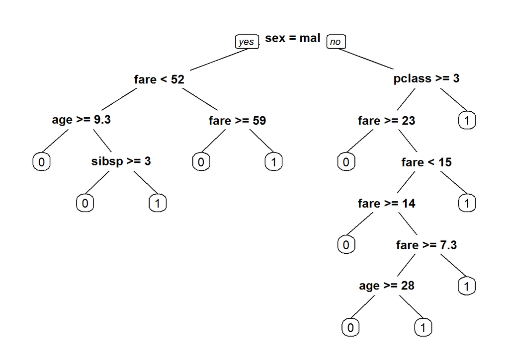

```r
#I again made a fit modell using all variables available, this time to predict the data survived.
fit_survived<-rpart(survived~pclass+sex+sibsp+age+parch+fare+embarked+family,data=train,method="class")

prp(fit_survived)
```

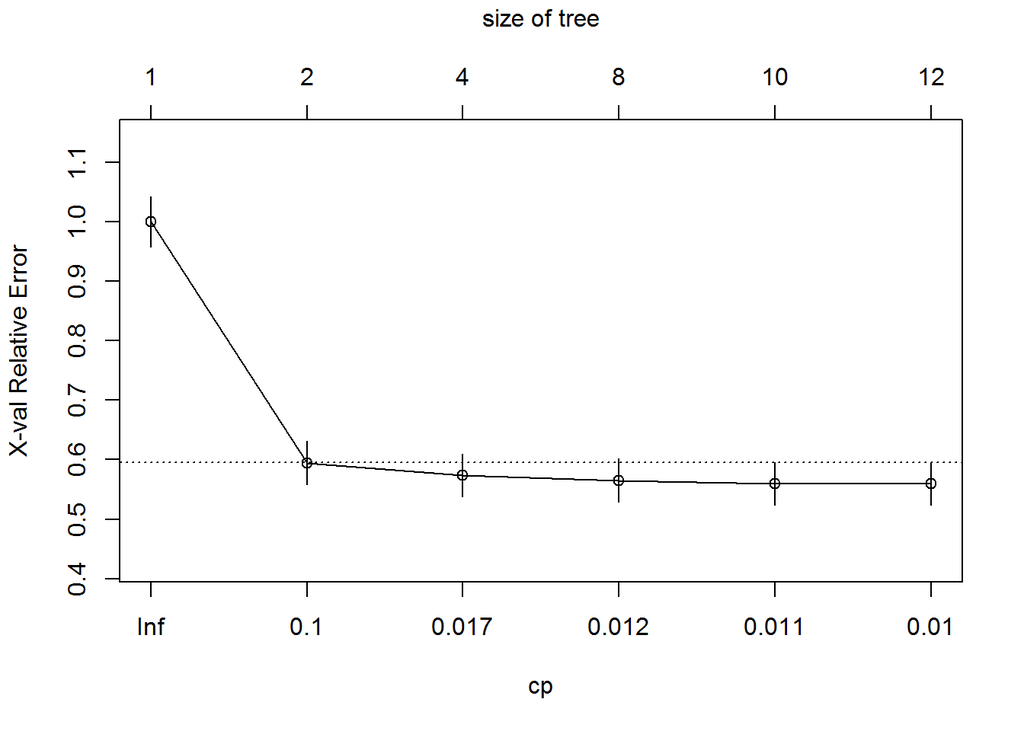

```r
plotcp(fit_survived)
```

### Random Forest

So I used the Random Forest technique, which is basically a combination of multiples regression trees, crossing multiple combinations. In the plot below we checked the errors from the random forest algorithm, in red for the non survivors, green for the survivors and black for the central line combining both errors. By this plot it is possible to say that our model predict better the destiny from those who have not survived than for those who did. It is explained because there are more people who have not survived the Titanic than otherwise, therefore the data available for the non survivors is larger, turning the prediction for them more accurate.

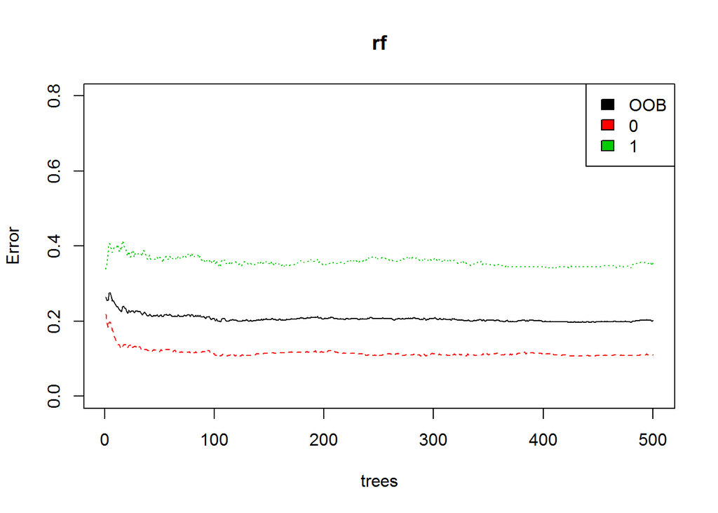

```r
plot(rf,ylim=c(0,0.8))
legend('topright',colnames(rf$err.rate),col=1:3,fill=1:3)
```

## Conclusion

```r
kable(error)
```

| combined_error | non_survivor | survivor |
| --- | --- | --- |
| 0.1965066 | 0.1050788 | 0.338843 |